# Ford GoBike Data Exploration

## by Jumba Mark

## Investigation Overview

- In this investigation, I wanted to focus on the following questions:
  1. when are most trips taken in terms of time of day and day of week
  2. How long does the average trip take?
  3. Does the above depend on if a user is a subscriber or customer?

## Dataset Overview

This data includes information about 183412 individual rides made in a bike-sharing system covering the greater San Francisco Bay area in the month of February. The attributes included duration, user type, start/end time, as well as additional information such as bike id, rental access method, start/end station, etc. The dataset was cleaned by removing outliers in the Exploration step while erroneous data types were corrected in the wrangling step. The following columns that were not related to the research questions were removed; `start_station_id`, `start_station_name`,`end_station_id`, `end_station_name`, and `bike_id`

## Distribution of Bikes Ride Duration

Bike ride duration in the dataset take on a very large range of values, from `61` at the lowest to `84548` at the highest. By removing outliers and plotting on a logarithmic scale, the distribution of bike ride duration look more like normal distribution with peak at little less than 500 seconds. Most bike rides are short trips.

[figure not shown]

## Ford GoBike User Types

Majority of the bike users are subscribers(90.5%). Customers take up 9.5%

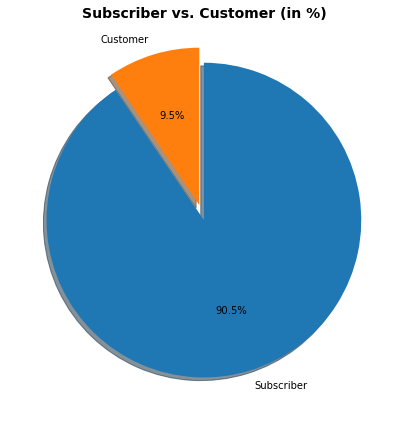

## Average Ride Duration: Subscribers vs. Customers

Although subscribers make a lot more trips than customers, customers generally take longer bike trip than subscribers.

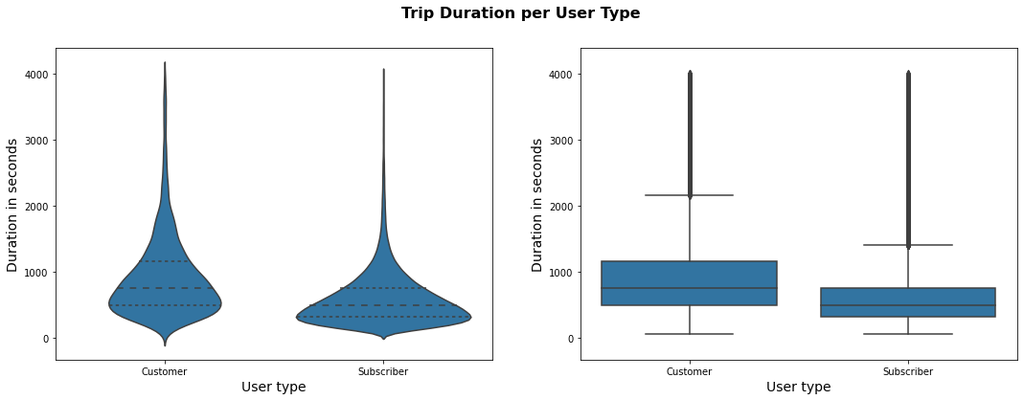

## Bike Usage in Hour and Day: Subscribers vs. Customers

- Different user types does show different usage(in number of rides) patterns.
  - Subscribers take most of their trips around 7-9am(peak at 8am) and 4-6pm(peak at 5pm), typical commute hours. They are probably commuters to work/school. Subscribers took more trips during the weekdays and less on weekend.
  - The usage trend for customers is relatively constant during the week but with higher usage on Thursday and Friday. Customers show similar pattern with subscribers on a daily basis except that customers take less morning trips.

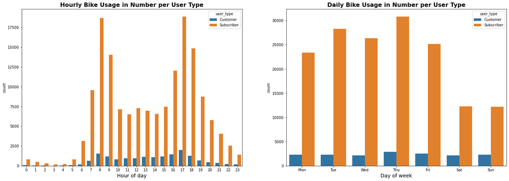

## Average Bike Trip Duration in Hour and Day: Subscribers vs. Customers

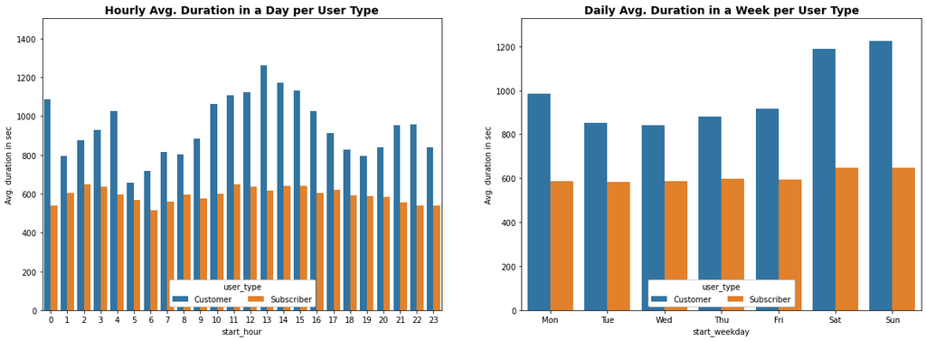

## Bike Rides 24x7: Subscribers vs. Customers

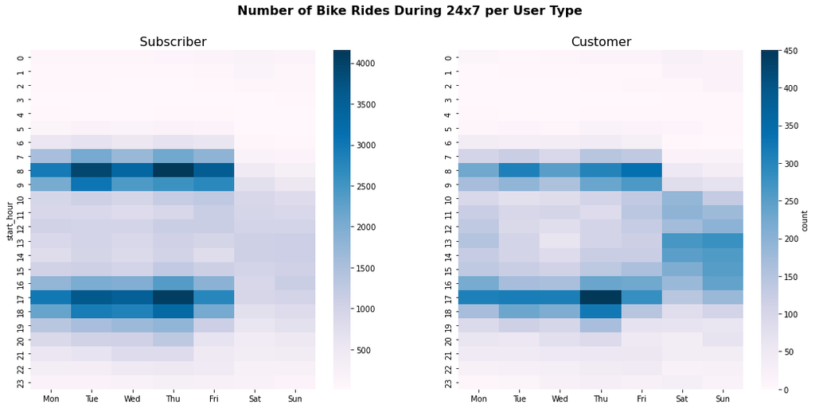